# Predicting DFS NBA Scores with XGBoost in R - Tutorial #1

RSH / QS3

2/14/2018

This is a brief tutorial and example of using Extreme Gradient Boosting using XGBoost in R. What we are trying to do is predict daily fantasy scores (Draft Kings Scoring) for NBA players based on historical data.

Please test out the python webscraper I developed at https://github.com/ronaldsholt/NBA_auto_web_scrape to easily pull historical data from Fantasy Cruncher’s Line Up Rewind.

For more details on XGBoost take a look the the docs here: https://cran.r-project.org/web/packages/xgboost/vignettes/xgboostPresentation.html

```r
library(readr)
sample_data <- read_delim("~/Desktop/DS_Modeling_Project/Fantasy_NBA/combined_nba_data.csv",
                         ",", escape_double = FALSE, trim_ws = TRUE)
#View(train_data)

train_data <- na.omit(sample_data)

library(dplyr)
library(car)
library(xgboost)
```

#### Data Wrangling & Pre-Processing

1. On Fantasy Crunchers application there are several fields that need to be removed in this example.

```r
#create a new dataframe removing the features below...
f.c <- within(train_data, rm(`Proj Mins`, `My Proj`, Exposure, `FC Proj`, Value))
```

Next we will spilt up our data randomly using the package CaTools. We want to split our data into a training set to train our model, and a testing set that we will test our model.

```r
# split the data up randomly into training and test data
require(caTools)
set.seed(1131) #set a random see to be able to re-generate the split sections
sample = sample.split(f.c, SplitRatio = .80)
train = subset(f.c, sample == TRUE)
test  = subset(f.c, sample == FALSE)
```

In this example, we will not label-encode or use one-hot coding to encode our categoricals. Instead, use the str() function to list the variables in the data. We will remove the variables that are catogoricals (the first 7 if you downloaded from FC).

```r
str(train)
```

```
## Classes 'tbl_df', 'tbl' and 'data.frame':    8004 obs. of  20 variables:
##  $ X1        : int  0 1 2 3 5 6 7 8 9 10 ...
##  $ Unnamed: 0: int  0 1 2 3 5 6 7 8 9 10 ...
##  $ Player    : chr  "Kevin Durant" "Russell Westbrook" "James Harden" "Chris Paul" ...
##  $ Pos       : chr  "SF/PF" "PG" "PG/SG" "PG/SG" ...
##  $ Team      : chr  "GSW" "OKC" "HOU" "HOU" ...
##  $ Opp       : chr  "vs MEM" "vs UTA" "vs LAL" "vs LAL" ...
##  $ Def v Pos : chr  "13th" "8th" "14th" "28th" ...
##  $ VegasPts  : num  107 103 120 120 109 ...
##  $ Salary    : int  11600 11400 11000 9800 9200 9100 9000 8800 8500 8300 ...
##  $ Floor     : num  31.5 35.6 38.4 39.6 33.6 24.8 32.9 23.8 25.6 27.5 ...
##  $ Ceiling   : num  70.8 77.2 79 76.3 75 64 74.5 61.2 58.7 61.6 ...
##  $ FPG       : num  49.5 54.7 56.7 44.4 43.2 43.3 43.4 38.5 44.6 38.9 ...
##  $ FPPM      : num  1.45 1.52 1.61 1.43 1.27 1.33 1.23 1.05 1.22 1.15 ...
##  $ USG       : num  31.2 34.2 36.4 22.8 31.2 20.9 23.9 23.4 30.8 30.5 ...
##  $ FGA       : num  19 20.8 20.9 12.5 18.6 10.1 14.5 15.6 19.4 17.5 ...
##  $ MPG       : num  34.2 36 35.3 31 34.1 32.5 35.3 36.8 36.5 33.8 ...
##  $ Con       : int  77 78 80 76 73 74 73 72 79 75 ...
##  $ Mins      : int  33 27 43 25 31 21 37 34 34 29 ...
##  $ Score     : num  38 56 71.2 20.8 34.8 ...
##  $ Val       : num  3.3 4.9 6.5 2.1 3.8 3.4 5.4 4.1 3.6 5 ...
```

```r
name = test$Player
train <- train[, -(1:7)] #remove non_numericals from the training set.
test <- test[, -(1:7)]   #remove non_numericals from the testing set.

head(train)
```

```
## # A tibble: 6 x 13
##   VegasPts Salary Floor Ceiling   FPG  FPPM   USG   FGA   MPG   Con  Mins
##      <dbl>  <int> <dbl>   <dbl> <dbl> <dbl> <dbl> <dbl> <dbl> <int> <int>
## 1   106.75  11600  31.5    70.8  49.5  1.45  31.2  19.0  34.2    77    33
## 2   102.75  11400  35.6    77.2  54.7  1.52  34.2  20.8  36.0    78    27
## 3   120.50  11000  38.4    79.0  56.7  1.61  36.4  20.9  35.3    80    43
## 4   120.50   9800  39.6    76.3  44.4  1.43  22.8  12.5  31.0    76    25
## 5   109.25   9200  33.6    75.0  43.2  1.27  31.2  18.6  34.1    73    31
## 6    98.00   9100  24.8    64.0  43.3  1.33  20.9  10.1  32.5    74    21
## # ... with 2 more variables: Score <dbl>, Val <dbl>
```

```r
head(test)
```

```
## # A tibble: 6 x 13
##   VegasPts Salary Floor Ceiling   FPG  FPPM   USG   FGA   MPG   Con  Mins
##      <dbl>  <int> <dbl>   <dbl> <dbl> <dbl> <dbl> <dbl> <dbl> <int> <int>
## 1   102.75   9400  26.9    75.5  40.2  1.33  25.1  14.9  30.2    65    31
## 2    97.75   7700  17.9    53.6  39.7  1.15  28.5  15.5  34.4    74    35
## 3   105.25   7600  21.1    63.6  36.4  1.23  26.1  11.0  29.7    67    26
## 4   102.75   7400  15.6    59.5  38.1  1.04  25.6  17.0  36.7    67    30
## 5   105.25   7100  18.9    54.3  37.6  1.08  26.8  17.1  34.7    73    27
## 6   107.75   6400  17.0    59.4  34.1  1.32  27.6  13.5  25.8    65    21
## # ... with 2 more variables: Score <dbl>, Val <dbl>
```

#### Setting up XGBoost parameters

We want to use the boosting model for a regression problem. The model feeds in a data.matrix for your data, where the train[-12] is the position of the ‘Score’ for which we are calculating. A good source for general parameter setting is https://www.analyticsvidhya.com/blog/2016/03/complete-guide-parameter-tuning-xgboost-with-codes-python/

```
Booster = 'gbtree'

Objective = 'reg:linear'  - This defines the loss function to be minimized.

max.depth <- This is the maximum number of trees to be used. Typically values 3 - 10.

nrounds <- The number of iterations that will be run using the model.

eval_metric = "rmse"  - Root mean squared error, default for a regression.

eta <- This parameter is synonymous with 'learning rate'.

colsample_bytree <- Denotes the fraction of columns to be randomly samples for each tree (0 - 1).

seed <- This is our random seed for reproducing results.

verbose = 1 - This parm prints our the eval_metrics for each round.

print_every_n = The frequency that verbose prints. Helps consolidate space for writing.
```

Here I have limited nrounds to 100, but you can play around with these parameters.

```r
model_xgb1 <- xgboost(data.matrix(train[,-12]),
                      label=data.matrix(train[,12]),
                      booster = "gbtree",
                      objective="reg:linear",
                      nrounds=100,
                      max.depth=6,
                      eta=0.01,
                      colsample_bytree=0.8,
                      seed=235,
                      eval_metric="rmse",
                      eval_metric="mae",
                      eval_metric="logloss",
                      #alpha=0.1,
                      verbose = 1,
                      print_every_n = 250)
```

The next step is to run your test data through the trained model using the predict() function.

```r
test_xgb1 <- predict(model_xgb1, data.matrix(test))
```

Next, we will look at a few quick metrics of our model.

1. Looking at feature importance will help us better understand our data set. These will come in handy later when we dig deeper into our dataset.

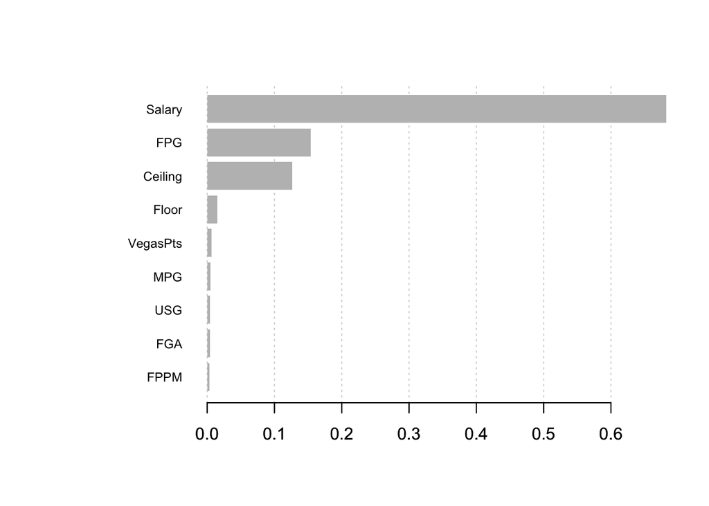

```r
xgb_imp_freq <- xgb.importance(feature_names = colnames(train), model = model_xgb1)
xgb.plot.importance(xgb_imp_freq)
```

```r
print(xgb_imp_freq)
```

```
##     Feature        Gain      Cover  Frequency  Importance
## 1:   Salary 0.682494307 0.28462342 0.12063878 0.682494307
## 2:      FPG 0.154096227 0.18444524 0.15500781 0.154096227
## 3:  Ceiling 0.126812363 0.25240457 0.17097726 0.126812363
## 4:    Floor 0.014812166 0.13194693 0.14528728 0.014812166
## 5: VegasPts 0.006115689 0.02897097 0.12393682 0.006115689
## 6:      MPG 0.004970573 0.03713968 0.08609616 0.004970573
## 7:      USG 0.003880397 0.02657043 0.07602847 0.003880397
## 8:      FGA 0.003803917 0.03782340 0.06110050 0.003803917
## 9:     FPPM 0.003014361 0.01607537 0.06092692 0.003014361
```

2. A quick check that I would run just for a visual of how your trainde model was predicting test values is running a linear regression on you predicted labels to your test labels.

Plotting the Score from our testing set acts as a quick validation method. the tighter the fit between out predicted values (test_xgb1) and our actual Y values in our test (test$Score) the better our model is at predicting.

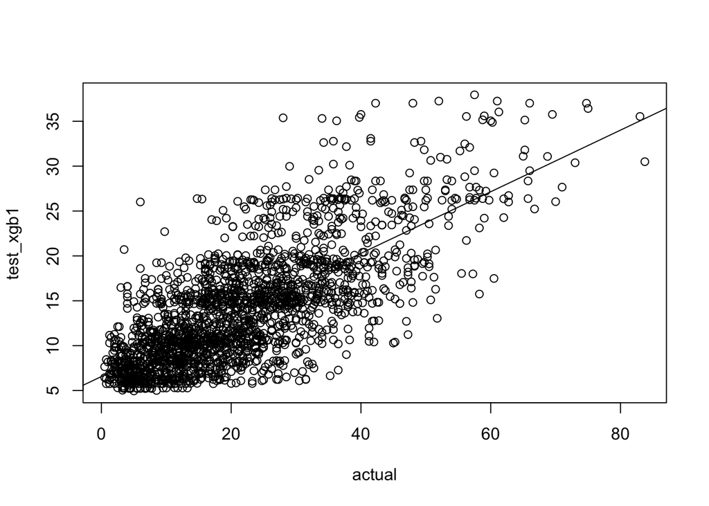

```r
actual <- test$Score      # y validation set
plot(test_xgb1 ~ actual)  #test_xgb1 are the y_predicted values from the XBG model
abline(lm(test_xgb1 ~ actual))
```

As you can see our model is positively trending, however, it looks likes we need to do some more work… Let’s try adding our categoricals to see if the model improves.

#### Feature Engineering

In this next part we will introduce our categoricals variables using one-hot encoding. We will evaluate if the model gets better when utilizing these variables. We will utilize one-hot encoding to encode our catagoricals.

```r
sample_data_2 <- read_delim("~/Desktop/DS_Modeling_Project/Fantasy_NBA/combined_nba_data.csv",
                          ",", escape_double = FALSE, trim_ws = TRUE)

train_data_2 <- na.omit(sample_data_2)
```

Here I am just re-adding the data like we did above.

```r
#create a new dataframe removing the features below...
f.c.2 <- within(train_data_2, rm(`Proj Mins`, `My Proj`, Exposure, `FC Proj`, Value))

f.c.2 <- filter(f.c.2, f.c.2$Score >= 10)
f.c.2 <- f.c.2[, -(1:6)]

# In this example we are only one-hot encoding the 'Def v Pos' or Defense verse the position.
ohe_feats = c('Def v Pos')
```

Here we call dummyVars from the package caret. Using this method we create the dummy variables and merge them back to the origional dataframe.

```r
library(caret)
dummies <- dummyVars(~ `Def v Pos`, data = f.c.2)
df_all_ohe <- as.data.frame(predict(dummies, newdata = f.c.2))
df_all_combined <- cbind(f.c.2[,-c(which(colnames(f.c.2) %in% ohe_feats))], df_all_ohe)
```

Next we are going to re-split our training and testing groups up…

```r
require(caTools)
set.seed(1131) #set a random see to be able to re-generate the split sections
sample = sample.split(df_all_combined, SplitRatio = .80)
train = subset(df_all_combined, sample == TRUE)
test  = subset(df_all_combined, sample == FALSE)
```

```r
head(train) #Notice the one-hot encoded variables...
```

```
##   VegasPts Salary Floor Ceiling  FPG FPPM  USG  FGA  MPG Con Mins Score
## 1   106.75  11600  31.5    70.8 49.5 1.45 31.2 19.0 34.2  77   33 38.00
## 2   102.75  11400  35.6    77.2 54.7 1.52 34.2 20.8 36.0  78   27 56.00
## 3   120.50  11000  38.4    79.0 56.7 1.61 36.4 20.9 35.3  80   43 71.25
## 4   120.50   9800  39.6    76.3 44.4 1.43 22.8 12.5 31.0  76   25 20.75
## 6   109.25   9200  33.6    75.0 43.2 1.27 31.2 18.6 34.1  73   31 34.75
## 7    98.00   9100  24.8    64.0 43.3 1.33 20.9 10.1 32.5  74   21 31.25
##   Val `Def v Pos`10th `Def v Pos`11th `Def v Pos`12th `Def v Pos`13th
## 1 3.3               0               0               0               1
## 2 4.9               0               0               0               0
## 3 6.5               0               0               0               0
## 4 2.1               0               0               0               0
## 6 3.8               0               0               0               0
## 7 3.4               0               0               1               0
##   `Def v Pos`14th `Def v Pos`15th `Def v Pos`16th `Def v Pos`17th
```

[output cut: 48 more lines]

We are going to use the same XGBoost model as before. Note in other examples and real-world problems you may want to spend a lot of time configuring the parameters to optimize your model. This resource was very helpful for me https://www.analyticsvidhya.com/blog/2016/03/complete-guide-parameter-tuning-xgboost-with-codes-python/

Note: for this markdown, I limited the nrounds to save resources.

```r
model_xgb1 <- xgboost(data.matrix(train[,-12]),
                      label=data.matrix(train[,12]),
                      booster = "gbtree",
                      objective="reg:linear",
                      nrounds=100,
                      max.depth=3,
                      eta=0.05,
                      colsample_bytree=0.8,
                      seed=235,
                      eval_metric="rmse",
                      eval_metric = "error",
                      alpha=0.1,
                      verbose = 1,
                      print_every_n = 100)
```

Run the prediction…

```r
test_xgb1 <- predict(model_xgb1, data.matrix(test))
```

Let’s take a quick look again with our plot…

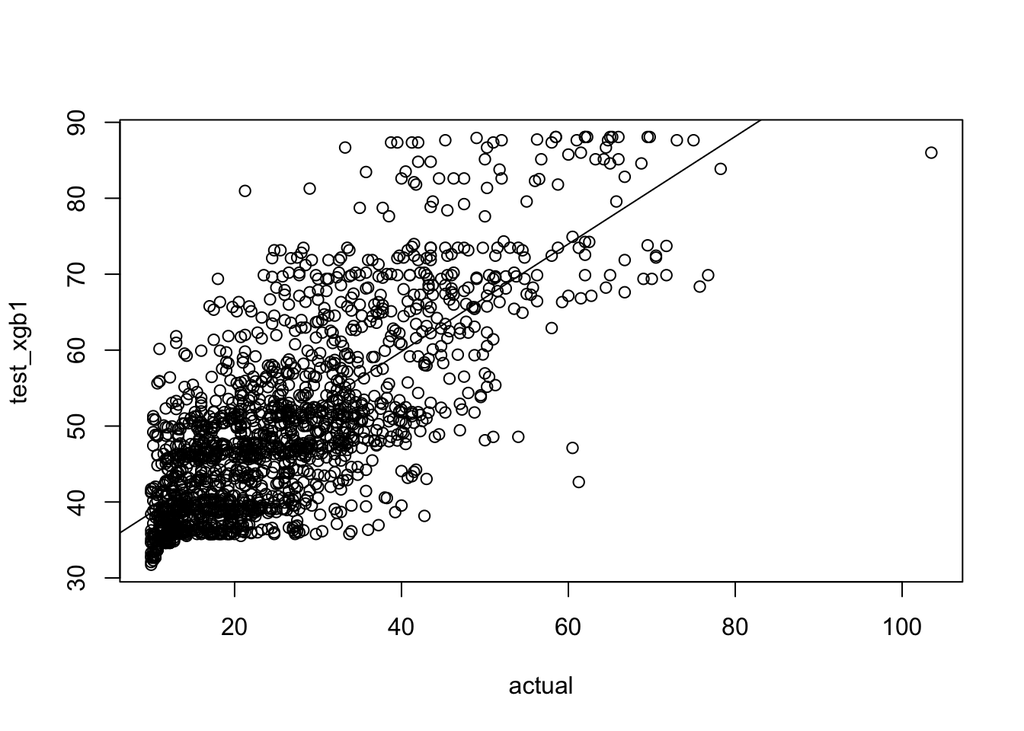

```r
actual <- test$Score
plot(test_xgb1 ~ actual)
abline(lm(test_xgb1 ~ actual))
```

```r
#xgb_imp_freq <- xgb.importance(feature_names = colnames(train), model = model_xgb1)
#xgb.plot.importance(xgb_imp_freq)
#print(xgb_imp_freq)
```

#### Next Steps

As you can see, adding Defense verse the position did not really improve our model, however, it gives you a decent idea of how to get XGBboost set up in R and running. There are a ton of parameter tuning, feature selection techniques, and other good stuff that we did not cover in this tutorial. What we will do in the next tutorial is go into a deeper dive of the exploratory space, and also explore some of the more complex ideas with XGBoost.

I hope this tutorial gave you just enough code “to break something”.